# Estatística

#### Distribuição condicional

Acabamos de ver o conceito de distribuição conjunta de duas variáveis. O conceito de distribuição conjunta dá origem ao conceito de distribuição condicional. Quando falamos em distribuição condicional, estamos interessados na distribuição de uma das variáveis impondo algumas condições sobre as outras. Para o caso discreto, temos que a distribuição de uma variável aleatória $X$ condicionada a outra variável $Y$ é dada por:

\begin{equation} P(X=x |Y=y)=\frac{P(X=x, Y=y)}{P(Y=y)} \end{equation}

Como exemplo: primeiramente, jogamos uma moeda, sendo que cara vale 1 e coroa vale 0. Se tirarmos cara jogamos a moeda novamente, mas se tirarmos coroa, jogamos um dado honesto de 6 lados. As pontuações das duas jogadas são dadas por $X_1$ e $X_2$. Qual, por exemplo, a probabilidade de se pontuar 3 na segunda jogada, sendo que pontuamos 1 na primeira jogada? É zero! Pois é impossível pontuar 3 jogando uma moeda (tiramos cara na primeira jogada). Matematicamente fica assim:

\begin{equation} P(X_2=3 |X_1=1)=\frac{P(X_2=3 ,X_1=1)}{P(X_1=1)}=\frac{0}{1/2}=0 \end{equation}

Um outro exemplo: qual a probabilidade de se pontuar 6 no total? A resposta fica assim:

\begin{equation} P(X_2+X_1=6)=P(X_2=6 ,X_1=0)=P(X_2=6 |X_1=0)P(X_1=0)=\frac{1}{6}\frac{1}{2}=\frac{1}{12} \end{equation}

Quando lidamos com variáveis contínuas, trabalhamos com densidades condicionadas. Não vamos entrar em aspectos muito teóricos aqui, vamos trabalhar com um exemplo muito útil na prática.

OBS: mais detalhes teóricos em https://pt.wikipedia.org/wiki/Distribui%C3%A7%C3%A3o_de_probabilidade_condicional

As análises a seguir serão feitas com base nas distribuições condicionais dos preços dos imóveis. A distribuição desta variável será condicionada à variável "waterfront", que é igual a um se o imóvel fica de frente para o mar e 0 se o imóvel não fica de frente para o mar. Como o preço é uma variável continua, visualizaremos box-plots condicionais e densidades condicionais. Vamos começar pelas densidades:

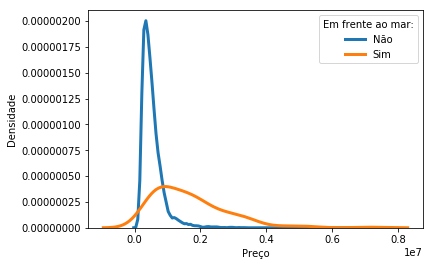

```python
groups = [0,1]
labels = ["Não","Sim"]

# Iterando
for group in groups:

    subset = data[data['waterfront'] == group]

    # Draw the density plot
    sns.distplot(subset['price'], hist = False, kde = True,
                 kde_kws = {'linewidth': 3},
                 label = labels[group])


# Plot formatting
plt.legend(prop={'size': 10}, title = 'Em frente ao mar:')
plt.xlabel('Preço')
plt.ylabel('Densidade')
plt.show()
```

É possível ver que quando o imóvel está em frente ao mar, o preço segue uma tendência de alta. Vamos ver mais a fundo essas distribuições condicionais olhando para os box-plots:

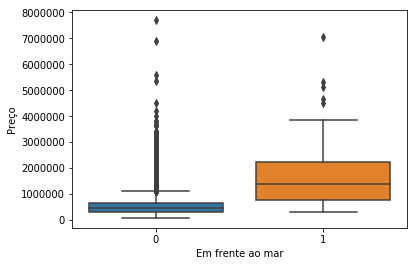

```python
sns.boxplot(x=data["waterfront"], y=data["price"])

plt.ylabel('Preço')
plt.xlabel('Em frente ao mar')
plt.show()
```

Agora veremos como uma distribuição conjunta pode ser condicionada a outra variável. Para isso, utilizaremos um *scatter plot* para visualizar as distribuições conjuntas do preço e e da área do imóvel condicionadas à variável "waterfront":

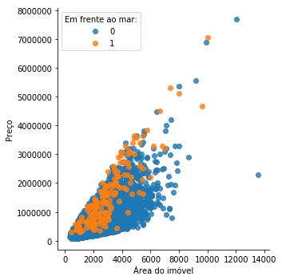

```python
sns.lmplot(x="sqft_living", y="price", data=data, fit_reg=False, hue="waterfront", legend=False, height=5)

plt.legend(prop={'size': 10}, title = 'Em frente ao mar:')
plt.ylabel('Preço')
plt.xlabel('Área do imóvel')
plt.show()
```

Traçando uma reta de tendência:

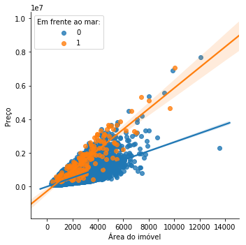

```python
sns.lmplot(x="sqft_living", y="price", data=data, fit_reg=True, hue="waterfront", legend=False, height=5)

plt.legend(prop={'size': 10}, title = 'Em frente ao mar:')
plt.ylabel('Preço')
plt.xlabel('Área do imóvel')
plt.show()
```

**Exercício:** que lição tiramos do gráfico acima?